# Horticulture Data- Table 7.2

#### Plot to show the change in production of fruits, plantation and vegetable over the year from 2014 -18

Plot by Satyam

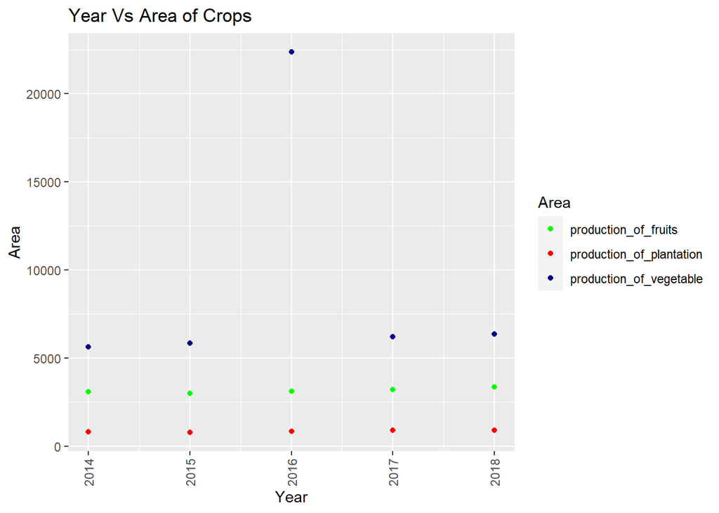

#### Plot to show the change in production of Spice, Flower and Medicinal over the year from 2014 -18

Plot by Satyam

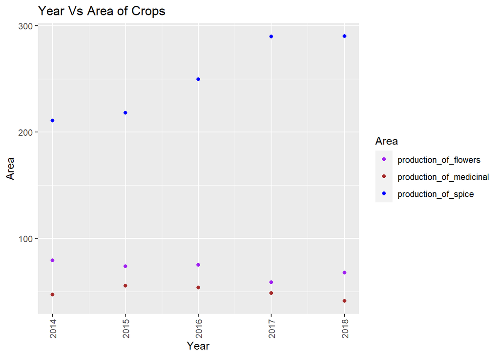

## Sukesh’s Data- Analysed tables 07_02_08, 07_02_10, 07_02_12, 07_02_14 and 07_02_16

All graph listed below are plotted by Sukesh #### Plot to show Highest Share of each Horticulture crop 2018

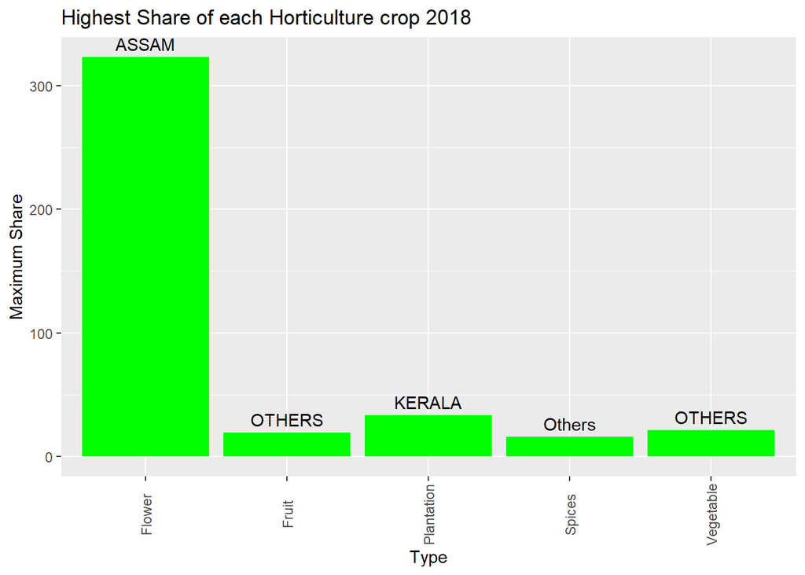

#### Plot of production vs region

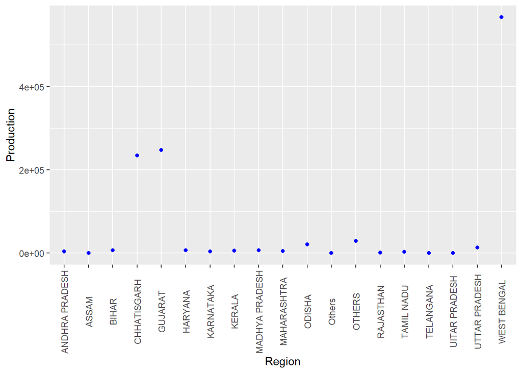

#### Plot of production vs Diffrent Crop type

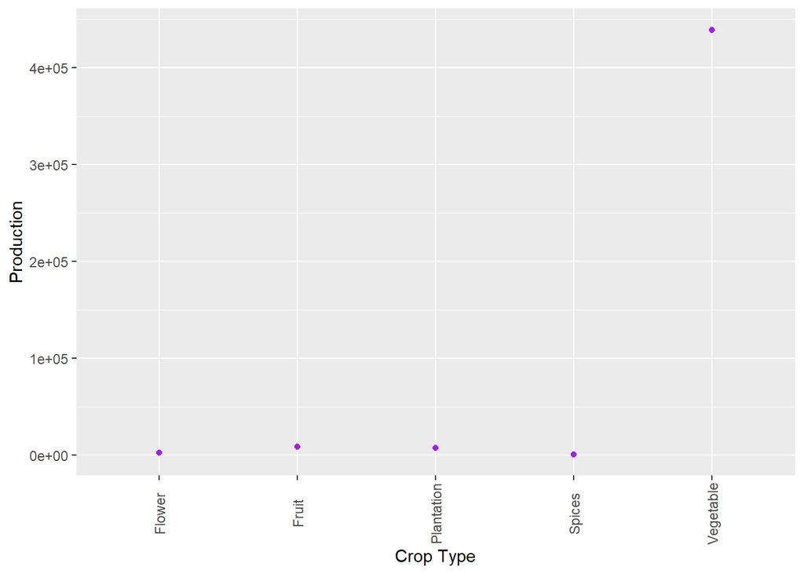

#### Plot of Share in % vs Diffrent Crop type

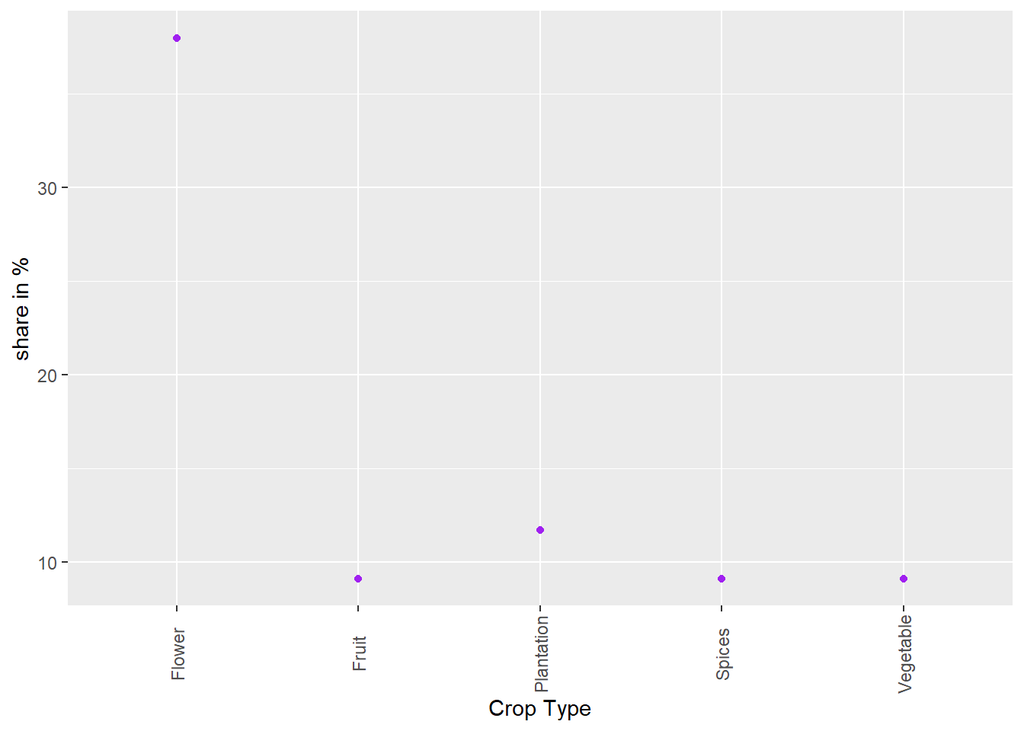

#### Plot of Production Share in % vs region

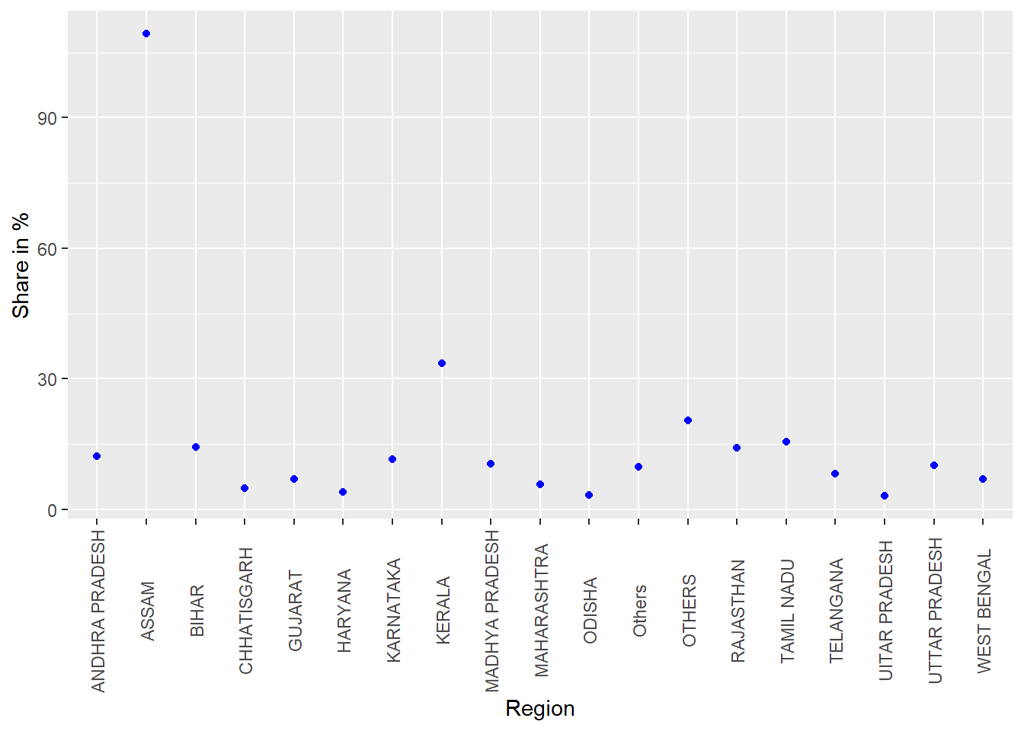